# Social Media Monitoring

[figure not shown]

## Lecture 3

## SM Monitoring: what's for?

- SM as news source
  - Civil journalism
  - UGC
- Marketing
  - Brand monitoring
  - Customers reviews
  - Loyal audience
  - Customers support

### Social Media - Brand Monitoring

More than a half takes into account internet reviews

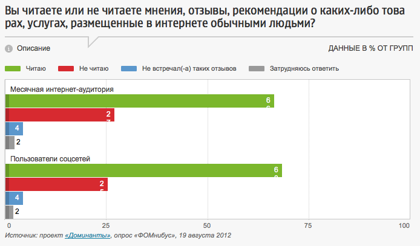

### Social Media - Brand Monitoring

More than a half takes into account internet reviews

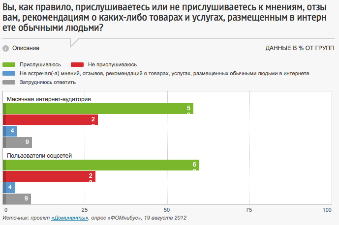

### Social Media - Brand Monitoring

But just a few authors produce reviews

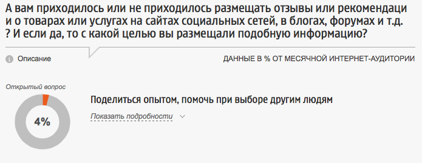

### Social Media - Brand Monitoring

## Fails:

- [United Breaks Guitars](http://www.youtube.com/watch?v=5YGc4zOqozo): –$180,000,000 (10%)

## and Wins:

- Morton's Steakhouse and Piter Shankman: ~1M mentions in Twitter

  [First tweet](https://twitter.com/petershankman/status/103936299983060993)

### Social Media - News Monitoring

- Disaster Response

  Red Cross Digital Ops: CRM system based on Radian6

  2011, USA:

  49% of respondents would use social media channels to let friends and family know that they are safe

  44% would use Twitter or Facebook to try to request help
- Media: UGC

  You - Reporter, Ridus, etc.

## SM Monitoring at hand

- SM internal search tools
- Yandex blogs
- DIY

### Social Media search tools

- Twitter: one of the best. Has it's own [query language](https://dev.twitter.com/rest/public/search)

  smiles in queries, datetime markers, from & to attributes
- VK.com: last days are indexed good
- Facebook :-(

## But!

### All these networks are indexed by Yandex.Blogs

### When search engine is enough

- Daily mentions rate < 100…999
- Estimate is OK
- Budget issues

### Search engine issue

- It's main goal - to find relevant document(s)
- Ideal search engine should return **1** document /best matching/
- Monitoring systems should return everything
- Solution: specify query, extended search only!
- Putin: 375k without specs, 501k during 1 month

### Yandex query language

AND, OR, NOT - basic logic constructions

Yandex specific issues:

- & – looks only inside 1 sentense
- ! - letter to start
- !! - normal form
- ~ - NOT
- | - OR
- [Other](http://help.yandex.ru/search/query-language/crib-sheet.xml)

### DIY-approach

We used for competitors analysis.

Thorough API

Issues:

- Specific sources
- Special content types

## SM Monitoring tools

- IQBuzz
- Brand Analytics
- YouScan
- Wobot
- Babkee
- Radian6
- Lithium
- Sysomos

### Monitoring sevices - RUS

Almost the same

I have one slide for each system, but it's too boring

Babkee, Wobot, BuzzLook, YouScan, Brand Analytics, IQBuzz

Two main features to compare:

- Sources (database volume)
- Interface

Add-on:

- “killer-features”

### Babkee

Should never be used :)

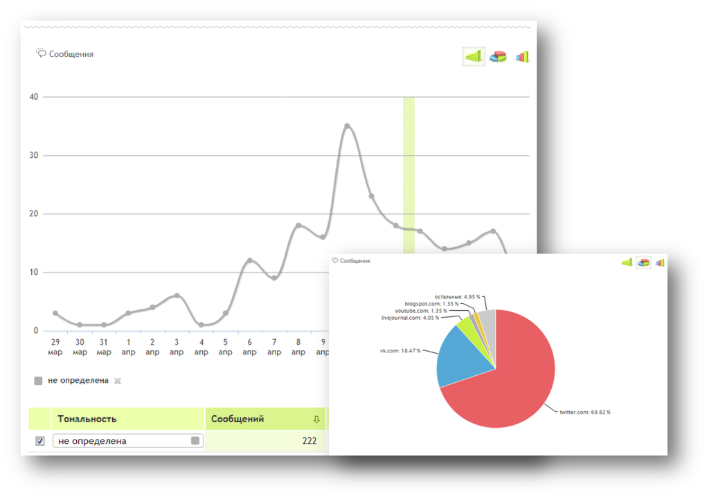

- Poorest database
- No query language
- Limited query string

### Wobot (or YouScan, or SemanticForce)

Good enough for simple tasks

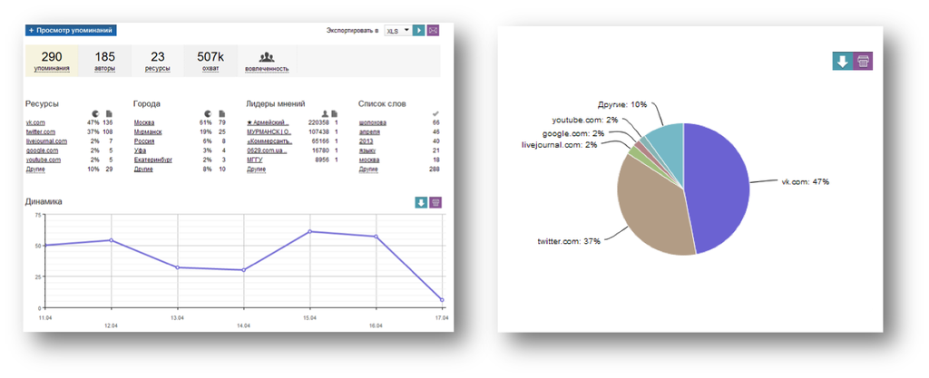

- Reasonable database
- No complicated queries
- Mandatory manager participation

### BuzzLook

Middling system

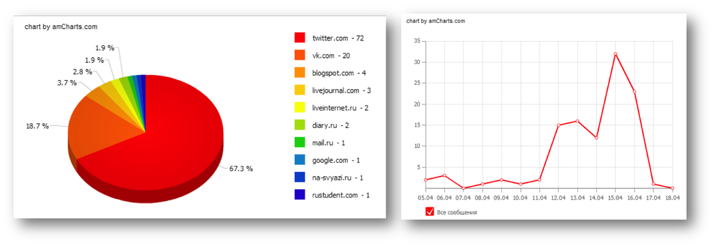

- So-so database
- Query language by Yandex

### IQBuzz

Top-2 system (I think so)

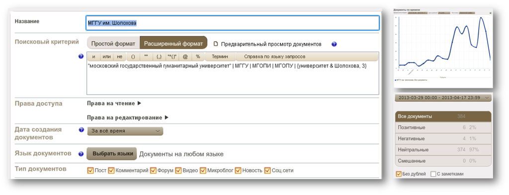

- Relevant database
- Complicated query language

### IQBuzz-2

- Interface features
  - Sub-folders
  - Topic extraction (Инфоповоды)
- New version (http://new.iqbuzz.ru)
  - widgets (exportable)
  - desktops

### Brand Analytics

Top-2 system

[figure not shown]

- Best database ever
- Simple interface
- Flexible management :)

### Database comparative studies (2011)

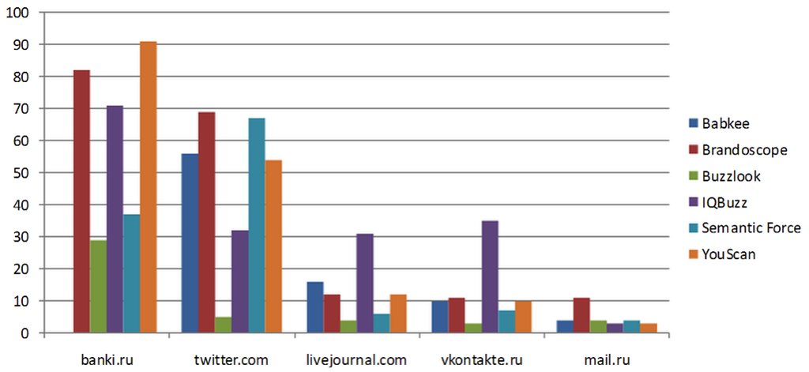

[Link](http://www.slideshare.net/Sky_Promo/2-10673972)

### Database comparative studies (2013)

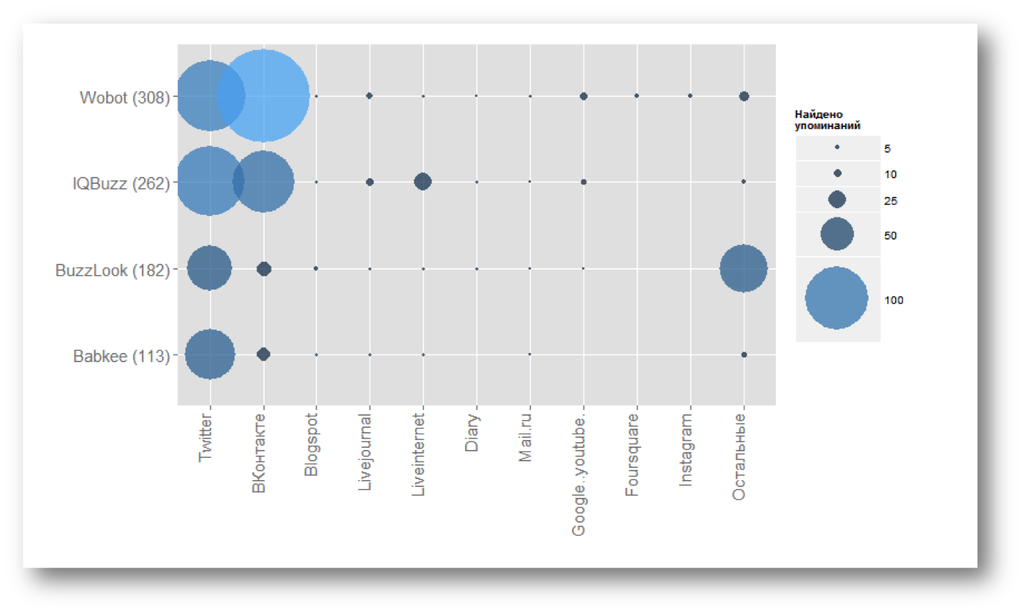

### Database comparative studies (2014...)

## Now:

- We have Brand Analytics
- Yandex indexes russian-speaking Facebook

### Complicated queries

Required to get exact what you are looking for.

Complicated tuning is not a defect!

/As lazy managers could think/

### Complicated queries

[figure not shown]

## Logic

- AND, &, && - every item
- OR, | - at least one item
- NOT, !, ~, - - not this item
- (), {} - grouping

## Help

- [Yandex](http://help.yandex.ru/search/?id=1111313)
- IQBuzz

### Mortal sins

1. Concatinating keywords without ANY operators (at least, when it's prohibited)
2. Mixing AND with OR in one block without hierarchy
3. Synonyms assumption: robots shouldn't merge synonnyms. People should.

### Just bragging :)

{(обострение | ухудшение | обострилась | ухудшилась) & (экологическая & обстановка), 5} | {(незаконная | незаконно | планируют) & (вырубка | вырубают | уничтожение | уничтожают), 3} | {(увеличились & огромные & катастрофические & вредные) & выбросы, 4} | {(нет | устарело | некачественное | “не работает” | плохой) & {очистное & (оборудование | сооружения | фильтр | электрофильтр), 3}, 5} | {(состояние | загрязнение) & (почвы |земли| среды | экологии | воды | воздуха| акватории), 4} | {несанкционированная & (свалка | стоянка), 3} | {(складирование | завал | свалка | полигон | захоронение | куча) & (мусор | отходы | вещества | ТБО | химический), 5} | {(уничтожение | вымирание | исчезают | ущерб | отравляют) & (флора | фауна | ландшафт | природа | леса), 5} | {{экологическая & (экспертиза | обстановка | проблема), 3} & (отсутствует | нарушена | нет | без | заключение), 5} | {(запах | выбросы | воняет) & (стирол | формальдегид | метилмеркаптан | сероводород | аммиак | фекалии | “выхлопные газы” | снижение), 4} | “построено *{2} незаконно” | {(вытекло | разлив) & (горючее | нефтепродуктов), 3} | “рост антропогенной нагрузки” | {“нарушение законодательства” & (водного | экологического), 3}

### Foreign systems

- [Sysomos](http://www.sysomos.com)
- [Radian6](https://login.radian6.com)
- [Crimson Hexagon](http://www.crimsonhexagon.com)

Issues:

- Language
- CRM-centered
- Top-3 RU Social Media: VK, OK, MM

## The End

## Bonus Track

[Lithium](http://www.lithium.com/products-solutions/social-media-management)

- Every incoming social post is automatically routed.
- Posts are scanned and assigned priorities.

[figure not shown]